# Outside Item Memory

> This notebook focuses on item memory outside the rooms.

# 1 Overview of the data

The rooms were separated into *Familiar* and *Novel* groups. Participants explored the *Familiar* group at the beginning of the experiment. In the encoding task, they visisted both *Familiar* and *Novel* groups. Their item memory (i.e., in which room they saw the item) was tested in the memory test the next day of the encoding task. **Novelty benefits** on the item memory are examined by comparing the memory performance between the *Familiar* and *Novel* groups.

Participants were also asked to rate how curious they felt about the room. The higher the rating is means they felt more curious about the room. Item memory as a function of curiosity rating was also examined for **curiosity benefits**.

Questionnaires on personal traits regarding curiosity were also administered to participants before the encoding task (i.e., PC and EC). Scores on these questionnaires might be able to predict the item memory or its relationship with curiosity rating.

In the encoding task, there were 6 objects in each room. It is possbile that the item memory for the object to some extent depends on the order in which the object was seen. For example, it may be easier to remember where the first and last objects were seen as compared to those in the middle.

# 2 Visual inspection of the data

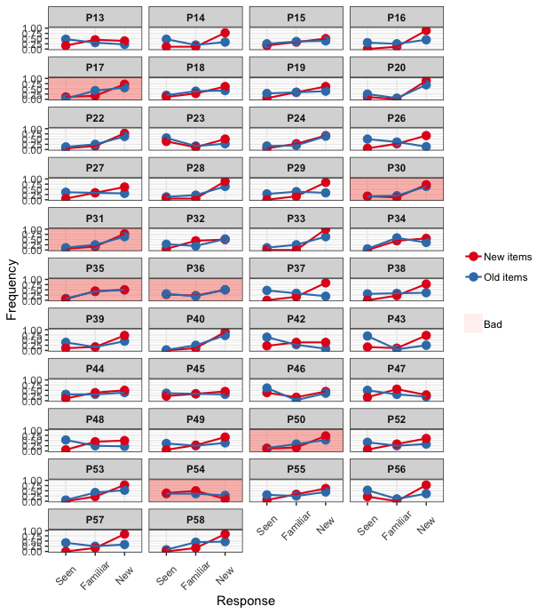

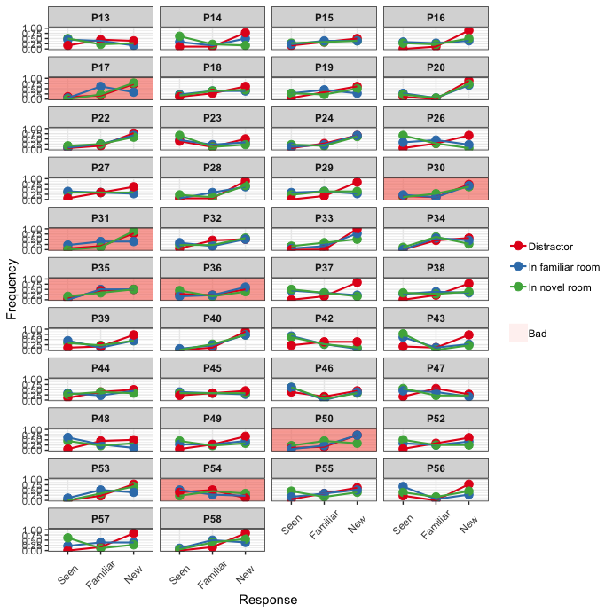

# 3 Novelty Benefits

We hypothesised that the memory for the items outside the rooms should be better for the *novel* rooms than for the *familiar* rooms.

## 3.1 Compare mean accuracy between *novel* and *familiar* rooms

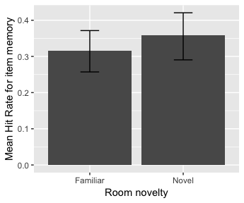

```
    Paired t-test

data:  MeanSeenHit by Group
t = -1.7259, df = 34, p-value = 0.09345
alternative hypothesis: true difference in means is not equal to 0
95 percent confidence interval:
 -0.09505093  0.00774934
sample estimates:
mean of the differences
            -0.04365079
```

## 3.2 Item memory as a function of item order

### 3.2.1 Visualise the data

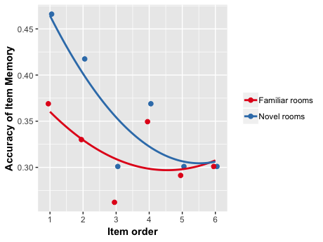

### 3.2.2 Testing novelty effects by fitting mixed models

Build models with item memory accuracy as $y$ and then examine effects of novelty by comparing the models.

- `baseline.item` is the model with only an intercept.
- `order.model.linear.1` is the model with $\small ItemOrder$ included, showing the effects of item order.
- `order.model.linear.2` is the model allowing the slope (i.e., relationship between item memory and item order) varying across participants.
- `order.model.quad.1` and `order.model.quad.2` repectively included $\small ItemOrder^2$ and related random effects.
- `novelty.model.1` is the model with $\small Group$ (i.e., *familiar* and *novel* rooms) included, examining the effects of novelty of the rooms on the intercept (i.e., mean item memory accuracy at the 1st order or overall if no difference in slope).
- `novelty.model.2` is the model with interaction between $\small Group$ and $\small ItemOrder$ included, examining the effects of novelty on how item memory accuracy changes as a function of item order.
- `novelty.model.3` included interaction between $\small Group$ and $\small ItemOrder^2$ for inestigating whether the pattern changes between *familiar* and *novel* groups.

|  | Model | df | AIC | BIC | logLik | Test | L.Ratio | p-value |
| --- | --- | --- | --- | --- | --- | --- | --- | --- |
| baseline.item | 1 | 3 | 1575.572 | 1590.930 | -784.7857 |  |  |  |
| order.model.linear.1 | 2 | 4 | 1569.481 | 1589.959 | -780.7405 | 1 vs 2 | 8.090475 | 0.0044 |
| order.model.linear.2 | 3 | 6 | 1567.224 | 1597.941 | -777.6117 | 2 vs 3 | 6.257518 | 0.0438 |
| order.model.quad.1 | 4 | 7 | 1567.592 | 1603.429 | -776.7959 | 3 vs 4 | 1.631726 | 0.2015 |
| order.model.quad.2 | 5 | 10 | 1572.163 | 1623.359 | -776.0813 | 4 vs 5 | 1.429080 | 0.6987 |
| novelty.model.1 | 6 | 11 | 1571.320 | 1627.636 | -774.6599 | 5 vs 6 | 2.842807 | 0.0918 |
| novelty.model.2 | 7 | 12 | 1571.231 | 1632.666 | -773.6154 | 6 vs 7 | 2.089112 | 0.1484 |
| novelty.model.3 | 8 | 13 | 1573.153 | 1639.709 | -773.5767 | 7 vs 8 | 0.077306 | 0.7810 |

#### 3.2.2.1 Parameter estimation for the complete model

```
Linear mixed-effects model fit by maximum likelihood
 Data: Curiosity.Recall.Old[!SubjectNo %in% bad.ps]
```

|  | AIC | BIC | logLik |
| --- | --- | --- | --- |
|  | 1573.153 | 1639.709 | -773.5767 |

```
Random effects:
 Formula: ~1 + ItemOrder + I(ItemOrder^2) | SubjectNo
 Structure: General positive-definite, Log-Cholesky parametrization
               StdDev     Corr
(Intercept)    0.24789219 (Intr) ItmOrd
ItemOrder      0.09672729 -0.529
I(ItemOrder^2) 0.01188265  0.200 -0.917
Residual       0.43742703

Fixed effects: SeenHit ~ ItemOrder + I(ItemOrder^2) + Group + ItemOrder:Group +      I(ItemOrder^2):Group
```

|  | Value | Std.Error | DF | t-value | p-value |
| --- | --- | --- | --- | --- | --- |
| (Intercept) | 0.3993254 | 0.08799562 | 1196 | 4.538015 | 0.0000 |
| ItemOrder | -0.0456406 | 0.05316636 | 1196 | -0.858450 | 0.3908 |
| I(ItemOrder^2) | 0.0050466 | 0.00735351 | 1196 | 0.686278 | 0.4927 |
| GroupNovel | 0.1417476 | 0.10930340 | 1196 | 1.296827 | 0.1949 |
| ItemOrder:GroupNovel | -0.0404993 | 0.07150927 | 1196 | -0.566350 | 0.5713 |
| I(ItemOrder^2):GroupNovel | 0.0027739 | 0.01000024 | 1196 | 0.277386 | 0.7815 |

```
 Correlation:
                          (Intr) ItmOrd I(ItO^2) GrpNvl ItO:GN
ItemOrder                 -0.856
I(ItemOrder^2)             0.748 -0.973
GroupNovel                -0.621  0.626 -0.581
ItemOrder:GroupNovel       0.578 -0.673  0.666   -0.931
I(ItemOrder^2):GroupNovel -0.530  0.658 -0.680    0.854 -0.979

Standardized Within-Group Residuals:
       Min         Q1        Med         Q3        Max
-1.6556008 -0.7112816 -0.3920611  1.0850890  2.1875017

Number of Observations: 1236
Number of Groups: 35
```

```
Linear mixed-effects model fit by maximum likelihood
 Data: Curiosity.Recall.Old[!SubjectNo %in% bad.ps]
```

|  | AIC | BIC | logLik |
| --- | --- | --- | --- |
|  | 1571.32 | 1627.636 | -774.6599 |

```
Random effects:
 Formula: ~1 + ItemOrder + I(ItemOrder^2) | SubjectNo
 Structure: General positive-definite, Log-Cholesky parametrization
               StdDev     Corr
(Intercept)    0.24729174 (Intr) ItmOrd
ItemOrder      0.09593506 -0.526
I(ItemOrder^2) 0.01178294  0.193 -0.916
Residual       0.43783904

Fixed effects: SeenHit ~ ItemOrder + I(ItemOrder^2) + Group
```

|  | Value | Std.Error | DF | t-value | p-value |
| --- | --- | --- | --- | --- | --- |
| (Intercept) | 0.4491667 | 0.07000973 | 1198 | 6.415776 | 0.0000 |
| ItemOrder | -0.0658917 | 0.03929080 | 1198 | -1.677027 | 0.0938 |
| I(ItemOrder^2) | 0.0064337 | 0.00538562 | 1198 | 1.194599 | 0.2325 |
| GroupNovel | 0.0420712 | 0.02494819 | 1198 | 1.686342 | 0.0920 |

```
 Correlation:
               (Intr) ItmOrd I(IO^2
ItemOrder      -0.793
I(ItemOrder^2)  0.662 -0.968
GroupNovel     -0.178  0.000  0.000

Standardized Within-Group Residuals:
       Min         Q1        Med         Q3        Max
-1.5850654 -0.7282468 -0.3968989  1.0795028  2.1512535

Number of Observations: 1236
Number of Groups: 35
```

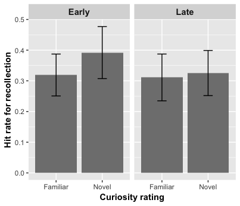

#### 3.2.3.1 Stats on it

```
Linear mixed-effects model fit by maximum likelihood
 Data: Curiosity.Recall.Old.Collapsed.Grp[!SubjectNo %in% bad.ps]
```

|  | AIC | BIC | logLik |
| --- | --- | --- | --- |
|  | -56.60131 | -24.24324 | 39.30065 |

```
Random effects:
 Formula: ~Group + ItemOrderType | SubjectNo
 Structure: General positive-definite, Log-Cholesky parametrization
                  StdDev     Corr
(Intercept)       0.17141564 (Intr) GrpNvl
GroupNovel        0.07223541  0.058
ItemOrderTypeLate 0.11111116 -0.428  0.041
Residual          0.12857632

Fixed effects: SeenHit ~ Group * ItemOrderType
```

|  | Value | Std.Error | DF | t-value | p-value |
| --- | --- | --- | --- | --- | --- |
| (Intercept) | 0.3190476 | 0.03674843 | 102 | 8.681940 | 0.0000 |
| GroupNovel | 0.0730159 | 0.03355491 | 102 | 2.176011 | 0.0319 |
| ItemOrderTypeLate | -0.0079365 | 0.03654547 | 102 | -0.217168 | 0.8285 |
| GroupNovel:ItemOrderTypeLate | -0.0587302 | 0.04410131 | 102 | -1.331710 | 0.1859 |

```
 Correlation:
                             (Intr) GrpNvl ItmOTL
GroupNovel                   -0.377
ItemOrderTypeLate            -0.541  0.404
GroupNovel:ItemOrderTypeLate  0.300 -0.657 -0.603

Standardized Within-Group Residuals:
         Min           Q1          Med           Q3          Max
-1.720999875 -0.495664229 -0.004621926  0.514606525  2.092699489

Number of Observations: 140
Number of Groups: 35
```

# 4 Curiosity Benefits

We hypothesed that the higher the curiosity rating was, the better the item memory should be.

## 4.1 Mean accuracy of item memory as a function of curiosity rating

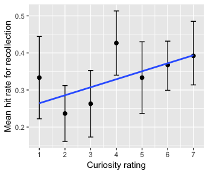

### 4.1.1 Testing the relationship between mean accuracy of item memory and curiosity rating

Build models with item memory accuracy as $y$ and examine effects of curiosity rating by including it into the model and then comparing the model fits.

- `baseline.rating` is the model with only an intercept, showing no change in item memory as a function of curiosity rating.
- `rating.intercept` is the model with $\small CuriosityRating$ included, showing the effects of curiosity rating.
- `rating.slope` is the model allowing the slope (i.e., relationship between item memory and curiosity rating) varying across participants.

|  | Model | df | AIC | BIC | logLik | Test | L.Ratio | p-value |
| --- | --- | --- | --- | --- | --- | --- | --- | --- |
| baseline.rating | 1 | 3 | -43.94646 | -33.96283 | 24.97323 |  |  |  |
| rating.intercept | 2 | 4 | -46.72931 | -33.41781 | 27.36466 | 1 vs 2 | 4.782857 | 0.0287 |
| rating.slope | 3 | 6 | -45.81844 | -25.85119 | 28.90922 | 2 vs 3 | 3.089131 | 0.2134 |

```r
summary(rating.intercept)
```

```
Linear mixed-effects model fit by maximum likelihood
 Data: OutsideObjectsMemory[!SubjectNo %in% bad.ps]
```

|  | AIC | BIC | logLik |
| --- | --- | --- | --- |
|  | -46.72931 | -33.41781 | 27.36466 |

```
Random effects:
 Formula: ~1 | SubjectNo
        (Intercept)  Residual
StdDev:   0.1546843 0.1843958

Fixed effects: SeenHit ~ CuriosityRating
```

|  | Value | Std.Error | DF | t-value | p-value |
| --- | --- | --- | --- | --- | --- |
| (Intercept) | 0.26846643 | 0.04295072 | 170 | 6.250568 | 0.0000 |
| CuriosityRating | 0.01556096 | 0.00710752 | 170 | 2.189367 | 0.0299 |

```
 Correlation:
                (Intr)
CuriosityRating -0.731

Standardized Within-Group Residuals:
        Min          Q1         Med          Q3         Max
-2.37834976 -0.68753742 -0.02809936  0.60898999  2.53791173

Number of Observations: 206
Number of Groups: 35
```

#### 4.1.1.2 Plot the model

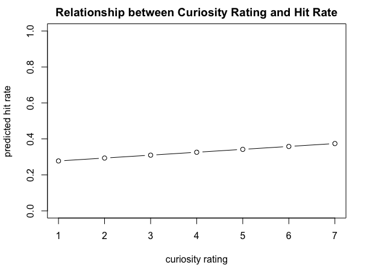

## 4.2 Does the relationship with curiosity rating depend on item order?

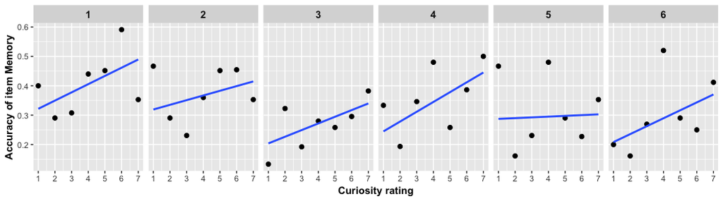

For almost all of the orders, there was a positive trend.

### 4.2.1 Testing the effect of item order

Build models with context memory accuracy as $y$ and examine effects of curiosity rating and item order by comparing the models.

- `item.model.linear.1` is the model with $\small ItemOrder$ included (in addition to $\small CuriosityRating$), showing the effects of item order.
- `item.model.linear.2` is the model allowing the slope (i.e., relationship between item memory and item order) varying across participants.
- `item.model.linear.3` is the model with the interaction between $\small ItemOrders$ and $\small CuriosityRating$ included.
- `item.model.quad.1` and `item.model.quad.2` repectively included $\small ItemOrder^2$ and related random effects.
- `item.model.quad.3` included interaction between $\small ItemOrder^2$ and $\small CuriosityRating$ for inestigating whether the pattern changes as a function of *curiosity rating*.

```r
rating.intercept <- update(baseline.item, .~. + CuriosityRating)
rating.slope     <- update(rating.intercept, random = ~ 1 + CuriosityRating | SubjectNo)
item.model.linear.1     <- update(rating.slope, .~. + ItemOrder)
item.model.linear.2     <- update(item.model.linear.1, random = list(~1+CuriosityRating|SubjectNo, ~1+ItemOrder|SubjectNo))
item.model.linear.3     <- update(item.model.linear.2, .~. + ItemOrder : CuriosityRating)
item.model.quad.1       <- update(item.model.linear.3, .~. + I(ItemOrder^2))
# item.model.quad.2       <- update(item.model.quad.1,   random = list(~1+CuriosityRating|SubjectNo, ~1+ItemOrder+I(ItemOrder^2)|SubjectNo)) - excluding this model because singularity issue (perhaps the model was getting too complex to be calculated)
item.model.quad.3       <- update(item.model.quad.1,   .~. + I(ItemOrder^2) : CuriosityRating)
anova(baseline.item, rating.intercept, rating.slope, item.model.linear.1, item.model.linear.2, item.model.linear.3, item.model.quad.1, item.model.quad.3)
```

|  | Model | df | AIC | BIC | logLik | Test | L.Ratio | p-value |
| --- | --- | --- | --- | --- | --- | --- | --- | --- |
| baseline.item | 1 | 3 | 1575.572 | 1590.930 | -784.7857 |  |  |  |
| rating.intercept | 2 | 4 | 1572.643 | 1593.122 | -782.3216 | 1 vs 2 | 4.928180 | 0.0264 |
| rating.slope | 3 | 6 | 1573.738 | 1604.456 | -780.8692 | 2 vs 3 | 2.904944 | 0.2340 |
| item.model.linear.1 | 4 | 7 | 1567.516 | 1603.354 | -776.7582 | 3 vs 4 | 8.221905 | 0.0041 |
| item.model.linear.2 | 5 | 10 | 1567.122 | 1618.318 | -773.5608 | 4 vs 5 | 6.394867 | 0.0939 |
| item.model.linear.3 | 6 | 11 | 1569.096 | 1625.412 | -773.5480 | 5 vs 6 | 0.025525 | 0.8731 |
| item.model.quad.1 | 7 | 12 | 1569.436 | 1630.872 | -772.7180 | 6 vs 7 | 1.660042 | 0.1976 |
| item.model.quad.3 | 8 | 13 | 1571.387 | 1637.942 | -772.6936 | 7 vs 8 | 0.048884 | 0.8250 |

```r
summary(item.model.linear.2 )
```

```
Linear mixed-effects model fit by maximum likelihood
 Data: Curiosity.Recall.Old[!SubjectNo %in% bad.ps]
```

|  | AIC | BIC | logLik |
| --- | --- | --- | --- |
|  | 1567.122 | 1618.318 | -773.5608 |

```
Random effects:
 Formula: ~1 + CuriosityRating | SubjectNo
 Structure: General positive-definite, Log-Cholesky parametrization
                StdDev     Corr
(Intercept)     0.14633016 (Intr)
CuriosityRating 0.02841864 -0.739

 Formula: ~1 + ItemOrder | SubjectNo %in% SubjectNo
 Structure: General positive-definite, Log-Cholesky parametrization
            StdDev     Corr
(Intercept) 0.20555983 (Intr)
ItemOrder   0.03406274 -0.874
Residual    0.43666261

Fixed effects: SeenHit ~ CuriosityRating + ItemOrder
```

|  | Value | Std.Error | DF | t-value | p-value |
| --- | --- | --- | --- | --- | --- |
| (Intercept) | 0.3352250 | 0.06004331 | 1199 | 5.583053 | 0.0000 |
| CuriosityRating | 0.0160449 | 0.00848244 | 1199 | 1.891538 | 0.0588 |
| ItemOrder | -0.0209035 | 0.00929427 | 1199 | -2.249072 | 0.0247 |

```
 Correlation:
                (Intr) CrstyR
CuriosityRating -0.599
ItemOrder       -0.647  0.000

Standardized Within-Group Residuals:
       Min         Q1        Med         Q3        Max
-1.6322202 -0.7265588 -0.3926011  1.0671439  2.1059965

Number of Observations: 1236
Number of Groups:
                 SubjectNo SubjectNo.1 %in% SubjectNo
                        35                         35
```

### 4.2.2 Collapse the order and curiosity rating

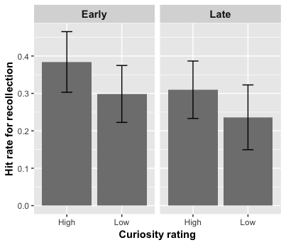

#### 4.2.2.1 Stats on it

```
Linear mixed-effects model fit by maximum likelihood
 Data: Curiosity.Recall.Old.Collapsed[!SubjectNo %in% bad.ps]
```

|  | AIC | BIC | logLik |
| --- | --- | --- | --- |
|  | -18.92049 | 12.95575 | 20.46025 |

```
Random effects:
 Formula: ~CuriosityRatingType + ItemOrderType | SubjectNo
 Structure: General positive-definite, Log-Cholesky parametrization
                       StdDev     Corr
(Intercept)            0.15310668 (Intr) CrsRTL
CuriosityRatingTypeLow 0.09083643 -0.368
ItemOrderTypeLate      0.04726435  0.072 -0.898
Residual               0.16914195

Fixed effects: SeenHit ~ CuriosityRatingType * ItemOrderType
```

|  | Value | Std.Error | DF | t-value | p-value |
| --- | --- | --- | --- | --- | --- |
| (Intercept) | 0.3841270 | 0.03915253 | 96 | 9.811039 | 0.0000 |
| CuriosityRatingTypeLow | -0.0755402 | 0.04523086 | 96 | -1.670103 | 0.0982 |
| ItemOrderTypeLate | -0.0742857 | 0.04184366 | 96 | -1.775316 | 0.0790 |
| CuriosityRatingTypeLow:ItemOrderTypeLate | 0.0120431 | 0.05944695 | 96 | 0.202585 | 0.8399 |

```
 Correlation:
                                         (Intr) CrsRTL ItmOTL
CuriosityRatingTypeLow                   -0.561
ItemOrderTypeLate                        -0.505  0.385
CuriosityRatingTypeLow:ItemOrderTypeLate  0.362 -0.660 -0.677

Standardized Within-Group Residuals:
        Min          Q1         Med          Q3         Max
-1.95612322 -0.68005464 -0.04910234  0.53350471  2.46085850

Number of Observations: 134
Number of Groups: 35
```

# 5 Curiosity and novelty

## 5.1 Testing the effects of curiosity rating and novelty together

Build models with item memory accuracy as $y$ and examine effects of curiosity rating and novelty together by including them into the model separately and then comparing the model fits.

|  | Model | df | AIC | BIC | logLik | Test | L.Ratio | p-value |
| --- | --- | --- | --- | --- | --- | --- | --- | --- |
| baseline.rating | 1 | 3 | -43.94646 | -33.96283 | 24.97323 |  |  |  |
| rating.intercept | 2 | 4 | -46.72931 | -33.41781 | 27.36466 | 1 vs 2 | 4.782857 | 0.0287 |
| rating.slope | 3 | 6 | -45.81844 | -25.85119 | 28.90922 | 2 vs 3 | 3.089131 | 0.2134 |
| novelty.model.1 | 4 | 7 | -43.87806 | -20.58293 | 28.93903 | 3 vs 4 | 0.059620 | 0.8071 |
| novelty.model.2 | 5 | 10 | -37.87833 | -4.59956 | 28.93916 | 4 vs 5 | 0.000261 | 1.0000 |
| interaction.model | 6 | 11 | -37.97637 | -1.36973 | 29.98819 | 5 vs 6 | 2.098047 | 0.1475 |

### 5.1.1 Check the complete model

```
Linear mixed-effects model fit by maximum likelihood
 Data: OutsideObjectsMemory[!SubjectNo %in% bad.ps]
```

|  | AIC | BIC | logLik |
| --- | --- | --- | --- |
|  | -37.97637 | -1.369735 | 29.98819 |

```
Random effects:
 Formula: ~1 + CuriosityRating | SubjectNo
 Structure: General positive-definite, Log-Cholesky parametrization
                StdDev     Corr
(Intercept)     0.15692034 (Intr)
CuriosityRating 0.03092764 -0.978

 Formula: ~1 + Group | SubjectNo %in% SubjectNo
 Structure: General positive-definite, Log-Cholesky parametrization
            StdDev     Corr
(Intercept) 0.12611548 (Intr)
GroupNovel  0.04395894 0.983
Residual    0.17328165

Fixed effects: SeenHit ~ CuriosityRating + Group + CuriosityRating:Group
```

|  | Value | Std.Error | DF | t-value | p-value |
| --- | --- | --- | --- | --- | --- |
| (Intercept) | 0.22885677 | 0.05748818 | 168 | 3.980936 | 0.0001 |
| CuriosityRating | 0.02780754 | 0.01515560 | 168 | 1.834803 | 0.0683 |
| GroupNovel | 0.13506398 | 0.12921691 | 168 | 1.045250 | 0.2974 |
| CuriosityRating:GroupNovel | -0.02922272 | 0.02422257 | 168 | -1.206425 | 0.2293 |

```
 Correlation:
                           (Intr) CrstyR GrpNvl
CuriosityRating            -0.852
GroupNovel                 -0.220  0.244
CuriosityRating:GroupNovel  0.396 -0.494 -0.940

Standardized Within-Group Residuals:
        Min          Q1         Med          Q3         Max
-2.08282392 -0.57837498 -0.03878704  0.57392638  2.44965337

Number of Observations: 206
Number of Groups:
                 SubjectNo SubjectNo.1 %in% SubjectNo
                        35                         35
```

## 5.2 What about the other way around

|  | Model | df | AIC | BIC | logLik | Test | L.Ratio | p-value |
| --- | --- | --- | --- | --- | --- | --- | --- | --- |
| baseline.rating | 1 | 3 | -43.94646 | -33.96283 | 24.97323 |  |  |  |
| novelty.model.1 | 2 | 4 | -44.59060 | -31.27909 | 26.29530 | 1 vs 2 | 2.6441416 | 0.1039 |
| novelty.model.2 | 3 | 6 | -41.17008 | -21.20282 | 26.58504 | 2 vs 3 | 0.5794827 | 0.7485 |
| rating.model.1 | 4 | 7 | -41.29741 | -18.00228 | 27.64870 | 3 vs 4 | 2.1273291 | 0.1447 |
| rating.model.2 | 5 | 10 | -37.87833 | -4.59956 | 28.93916 | 4 vs 5 | 2.5809150 | 0.4608 |
| interaction.model | 6 | 11 | -37.97637 | -1.36973 | 29.98819 | 5 vs 6 | 2.0980473 | 0.1475 |